# Project: EdTech Lead Conversion Prediction

## Introduction

This project leverages machine learning to enhance lead conversion in the EdTech sector, prioritize high-potential leads, and align marketing strategies with business growth objectives. It utilizes a dataset capturing lead interactions, demographics, marketing exposure, and behavioral patterns to extract actionable insights and optimize resource allocation effectively.

### Context

The EdTech industry, valued at $286.62 billion by 2023 (CAGR of 10.26% from 2018–2023), has rapidly expanded due to features like ease of access, personalized learning, and transparent assessments, making it a strong alternative to traditional education. The COVID-19 pandemic further accelerated this growth, increasing competition and the urgency to identify high-potential leads effectively.

EdTech companies like ExtraaLearn depend on generating and nurturing leads to convert potential customers into paid users. These leads stem from various sources, including website and app interactions, social media engagement, and email inquiries. Efficiently prioritizing high-potential leads is critical to improving conversion rates and optimizing resource allocation in a highly competitive landscape.

### Objective

ExtraaLearn, a startup offering programs in cutting-edge technologies, , seeks to maximize lead conversion and optimize resource allocation by identifying and targeting high-potential leads effectively. This project leverages lead interaction data to build predictive models, extract actionable insights, and refine marketing and sales strategies.

**Key Objectives**

- **Prediction**: Build a machine learning model to estimate lead conversion likelihood and prioritize high-potential leads.
- **Insight**: Identify key drivers of lead conversion to inform data-driven decision-making.
- **Optimization**: Develop lead profiles to enhance targeting strategies and streamline resource allocation.

**Machine Learning Models**

- **Logistic Regression**: Provides a probabilistic framework to predict lead conversion and identify key drivers.
- **Decision Tree**: Offers interpretable decision paths while capturing non-linear relationships in the data.
- **Random Forest**: Combines multiple decision trees for robust predictions and reduced overfitting.

### Data Dictionary

The dataset captures lead interactions, demographic details, marketing exposure, and behavioral patterns, providing critical inputs for predictive modeling and actionable insights:

- **ID**: Unique identifier for each lead.
- **age**: Age of the lead.
- **current_occupation**: Occupation of the lead is categorized as professional, unemployed or student.
- **first_interaction**: Initial interaction channel is website or mobile app.
- **profile_completed**: Profile completion percentage is classified as low (0-50%), medium (50-75%) or high (75-100%).
- **website_visits**: Number of website visits.
- **time_spent_on_website**: Total time spent on the website.
- **page_views_per_visit**: Average pages viewed per visit.
- **last_activity**: Most recent interaction via email (e.g., program details), phone (calls/SMS), or website (live chat/profile update).
- **print_media_type1**: Seen ad in the newspaper (yes/no).
- **print_media_type2**: Seen ad in magazines (yes/no).
- **digital_media**: Seen digital ads (yes/no).
- **educational_channels**: Learned about ExtraaLearn through forums or educational websites (yes/no).
- **status**: Indicates lead conversion to a paid customer (yes/no).
- **referral**: Referred by others (yes/no).

### Performance Metrics

The following metrics are used to evaluate the effectiveness of machine learning models and track the impact of business recommendations, ensuring alignment with the business objectives of maximizing lead conversions and optimizing resource allocation for growth.

**Predictive Metrics**

- **Accuracy**: Reflects overall model performance in correctly classifying leads. Higher accuracy indicates better general performance.
- **Precision**: Measures the proportion of true positives among all positive predictions, ensuring reliability in identifying converted leads, while reducing false positives.
- **Recall**: Measures the proportion of true positives among all actual conversions, ensuring reliability in capturing potential leads, while reducing false negatives.
- **F1 Score**: A harmonic mean of precision and recall, balancing the trade-off between these metrics.

**Business Key Performance Indicators (KPIs)**

- **Pages per Session**: Measures the average number of pages viewed during a single session, reflecting user engagement on the website.
- **Bounce Rate**: Indicates the percentage of visitors leaving the website without further interaction, highlighting engagement issues.
- **Lead Form Submissions**: Tracks the number of completed forms, providing insights into profile completion progress and lead generation.
- **Qualified Lead Rate (MQLs)**: Represents the percentage of leads meeting predefined marketing-qualified criteria, evaluating channel effectiveness.
- **Unique Visitors**: Measures the number of distinct individuals visiting the website, assessing the reach of targeted campaigns.
- **Cost per Lead (CPL)**: Reflects the average cost of acquiring a lead, ensuring marketing efficiency and alignment with ROI objectives.

## Importing Necessary Libraries and Data

This section initializes the environment by importing essential libraries for data processing, visualization, machine learning, and model evaluation, ensuring smooth execution of lead prediction analysis and performance benchmarking.

```python
# ----------------------------------------------------------------------
# Utility Libraries for Directory and File Handling
# ----------------------------------------------------------------------

import pickle  # For serializing and saving Python objects
import warnings  # For suppressing warnings

warnings.filterwarnings("ignore")
```

```python
# ----------------------------------------------------------------------
# Libraries for Data Manipulation, and Visualization
# ----------------------------------------------------------------------

# Data manipulation
import numpy as np
import pandas as pd
import math

# Data visualization
import matplotlib.pyplot as plt
import matplotlib.gridspec as gridspec
import seaborn as sns
%matplotlib inline

# Jupyter notebook display settings
from IPython.display import display, Markdown

# ----------------------------------------------------------------------
# Libraries for Machine Learning
# ----------------------------------------------------------------------

# Data preprocessing, classifiers, tuning, and evaluation
from sklearn.preprocessing import StandardScaler
from sklearn.model_selection import train_test_split
from sklearn.linear_model import LogisticRegression
from sklearn import tree
from sklearn.tree import DecisionTreeClassifier
from sklearn.ensemble import RandomForestClassifier
from sklearn.model_selection import GridSearchCV
from sklearn.metrics import confusion_matrix, classification_report, recall_score, precision_score, f1_score, accuracy_score
```

## Loading Data

This section focuses on loading the dataset into a pandas DataFrame, ensuring the data is structured and ready for analysis and machine learning model development.

```python
# Read the DataFrame | Single File
df = pd.read_csv("../data/raw/ExtraaLearn.csv")
```

## Data Overview

This section provides an overview of the dataset, summarizing its structure, data types, and key characteristics. It includes a review of duplicate records, unique value counts, and initial data observations to ensure data quality and readiness for further analysis. The cleaned and processed data is exported as a pickle file for efficient storage and future use.

### High-Level Data Information

```python
# Number of rows and columns
df.shape
```

```
(4612, 15)
```

```python
# First 5 rows
df.head()
```

|  | ID | age | current_occupation | first_interaction | profile_completed | website_visits | time_spent_on_website | page_views_per_visit | last_activity | print_media_type1 | print_media_type2 | digital_media | educational_channels | referral | status |
| --- | --- | --- | --- | --- | --- | --- | --- | --- | --- | --- | --- | --- | --- | --- | --- |
| 0 | EXT001 | 57 | Unemployed | Website | High | 7 | 1639 | 1.861 | Website Activity | Yes | No | Yes | No | No | 1 |
| 1 | EXT002 | 56 | Professional | Mobile App | Medium | 2 | 83 | 0.320 | Website Activity | No | No | No | Yes | No | 0 |
| 2 | EXT003 | 52 | Professional | Website | Medium | 3 | 330 | 0.074 | Website Activity | No | No | Yes | No | No | 0 |
| 3 | EXT004 | 53 | Unemployed | Website | High | 4 | 464 | 2.057 | Website Activity | No | No | No | No | No | 1 |
| 4 | EXT005 | 23 | Student | Website | High | 4 | 600 | 16.914 | Email Activity | No | No | No | No | No | 0 |

```python
# Last 5 rows
df.tail()
```

|  | ID | age | current_occupation | first_interaction | profile_completed | website_visits | time_spent_on_website | page_views_per_visit | last_activity | print_media_type1 | print_media_type2 | digital_media | educational_channels | referral | status |
| --- | --- | --- | --- | --- | --- | --- | --- | --- | --- | --- | --- | --- | --- | --- | --- |
| 4607 | EXT4608 | 35 | Unemployed | Mobile App | Medium | 15 | 360 | 2.170 | Phone Activity | No | No | No | Yes | No | 0 |
| 4608 | EXT4609 | 55 | Professional | Mobile App | Medium | 8 | 2327 | 5.393 | Email Activity | No | No | No | No | No | 0 |
| 4609 | EXT4610 | 58 | Professional | Website | High | 2 | 212 | 2.692 | Email Activity | No | No | No | No | No | 1 |
| 4610 | EXT4611 | 57 | Professional | Mobile App | Medium | 1 | 154 | 3.879 | Website Activity | Yes | No | No | No | No | 0 |
| 4611 | EXT4612 | 55 | Professional | Website | Medium | 4 | 2290 | 2.075 | Phone Activity | No | No | No | No | No | 0 |

```python
# Summary of DataFrame
df.info()
```

```
<class 'pandas.core.frame.DataFrame'>
RangeIndex: 4612 entries, 0 to 4611
Data columns (total 15 columns):
 #   Column                 Non-Null Count  Dtype
---  ------                 --------------  -----
 0   ID                     4612 non-null   object
 1   age                    4612 non-null   int64
 2   current_occupation     4612 non-null   object
 3   first_interaction      4612 non-null   object
 4   profile_completed      4612 non-null   object
 5   website_visits         4612 non-null   int64
 6   time_spent_on_website  4612 non-null   int64
 7   page_views_per_visit   4612 non-null   float64
 8   last_activity          4612 non-null   object
 9   print_media_type1      4612 non-null   object
 10  print_media_type2      4612 non-null   object
 11  digital_media          4612 non-null   object
 12  educational_channels   4612 non-null   object
 13  referral               4612 non-null   object
 14  status                 4612 non-null   int64
dtypes: float64(1), int64(4), object(10)
memory usage: 540.6+ KB
```

### Unique and Duplicate Values

```python
# Number of duplicate rows
dvalues = df.duplicated().sum()

# Convert into DataFrame
duplicate_df = pd.DataFrame({"metric": ["duplicate_rows"], "count": [dvalues]})

# Display DataFrame
duplicate_df
```

|  | metric | count |
| --- | --- | --- |
| 0 | duplicate_rows | 0 |

```python
# Number of unique values per feature
nuniq = df.nunique().reset_index()

# Rename column names
nuniq.columns = ["feature", "unique values"]

# Display DataFrame
nuniq
```

|  | feature | unique values |
| --- | --- | --- |
| 0 | ID | 4612 |
| 1 | age | 46 |
| 2 | current_occupation | 3 |
| 3 | first_interaction | 2 |
| 4 | profile_completed | 3 |
| 5 | website_visits | 27 |
| 6 | time_spent_on_website | 1623 |
| 7 | page_views_per_visit | 2414 |
| 8 | last_activity | 3 |
| 9 | print_media_type1 | 2 |
| 10 | print_media_type2 | 2 |
| 11 | digital_media | 2 |
| 12 | educational_channels | 2 |
| 13 | referral | 2 |
| 14 | status | 2 |

**Observations:**

- **Dimensions**: The dataset contains **4,612 rows** and **15 columns**.
- **Data Types**: Includes **5 numerical** features and **10 categorical**/textual features.
- **Data Integrity**: The dataset is free of missing values and duplicate entries, ensuring complete and reliable data.
- **Unique Identifiers**: The ID column is a unique identifier and will be excluded from analysis as it holds no analytical value.

### Data Preprocessing

```python
# Drop the column 'ID' from the data set
df.drop("ID", axis=1, inplace=True)
```

```python
# Select categorical and numerical columns
cat_cols = list(df.select_dtypes(include=["object"]).columns)
num_cols = list(df.select_dtypes(include=[np.number]).columns)
```

```python
# Create a mappping dictionary for the last_activity column
last_activity_map = {
    "website activity": "website",
    "email activity": "email",
    "phone activity": "phone",
}

# Standardize the feature values of last_activity column
df["last_activity"] = df["last_activity"].str.lower().map(last_activity_map)

# Standardize the feature values of categorical features to lower case
df[cat_cols] = df[cat_cols].applymap(lambda x: x.lower())

# Display the first few rows to verify the changes
df.head()
```

|  | age | current_occupation | first_interaction | profile_completed | website_visits | time_spent_on_website | page_views_per_visit | last_activity | print_media_type1 | print_media_type2 | digital_media | educational_channels | referral | status |
| --- | --- | --- | --- | --- | --- | --- | --- | --- | --- | --- | --- | --- | --- | --- |
| 0 | 57 | unemployed | website | high | 7 | 1639 | 1.861 | website | yes | no | yes | no | no | 1 |
| 1 | 56 | professional | mobile app | medium | 2 | 83 | 0.320 | website | no | no | no | yes | no | 0 |
| 2 | 52 | professional | website | medium | 3 | 330 | 0.074 | website | no | no | yes | no | no | 0 |
| 3 | 53 | unemployed | website | high | 4 | 464 | 2.057 | website | no | no | no | no | no | 1 |
| 4 | 23 | student | website | high | 4 | 600 | 16.914 | email | no | no | no | no | no | 0 |

### Export of Processed Data

```python
# Define the export path and filename for the processed and cleaned dataset
processed_data_filename = "../data/processed/processed_data.pkl"

# Export the dataset
with open(processed_data_filename, "wb") as f:
    pickle.dump(df, f)

# Print status log
print(f"Dimensions: {df.shape[0]} rows, {df.shape[1]} columns")
print(f"Processed data exported successfully to '{processed_data_filename}'")
```

```
Dimensions: 4612 rows, 14 columns
Processed data exported successfully to '../data/processed/processed_data.pkl'
```

## Exploratory Data Analysis (EDA)

This section conducts an exploratory data analysis (EDA) to examine lead demographics, interaction patterns, and key features, uncovering trends and relationships that inform lead conversion behavior and guide model development.

### Statistical Analysis of DataFrame

```python
# Set standard color palette for plotting
palette_color = sns.color_palette("Set2")
palette_alpha = 0.7
```

#### Analysis of Numerical Data

```python
# Statistical summary of numerical data
df[num_cols].describe().T.round(2)
```

|  | count | mean | std | min | 25% | 50% | 75% | max |
| --- | --- | --- | --- | --- | --- | --- | --- | --- |
| age | 4612.0 | 46.20 | 13.16 | 18.0 | 36.00 | 51.00 | 57.00 | 63.00 |
| website_visits | 4612.0 | 3.57 | 2.83 | 0.0 | 2.00 | 3.00 | 5.00 | 30.00 |
| time_spent_on_website | 4612.0 | 724.01 | 743.83 | 0.0 | 148.75 | 376.00 | 1336.75 | 2537.00 |
| page_views_per_visit | 4612.0 | 3.03 | 1.97 | 0.0 | 2.08 | 2.79 | 3.76 | 18.43 |
| status | 4612.0 | 0.30 | 0.46 | 0.0 | 0.00 | 0.00 | 1.00 | 1.00 |

**Observations:**

#### Analysis of Categorical Data

```python
# Statistical summary of categorical data
df[cat_cols].describe().T
```

|  | count | unique | top | freq |
| --- | --- | --- | --- | --- |
| current_occupation | 4612 | 3 | professional | 2616 |
| first_interaction | 4612 | 2 | website | 2542 |
| profile_completed | 4612 | 3 | high | 2264 |
| last_activity | 4612 | 3 | email | 2278 |
| print_media_type1 | 4612 | 2 | no | 4115 |
| print_media_type2 | 4612 | 2 | no | 4379 |
| digital_media | 4612 | 2 | no | 4085 |
| educational_channels | 4612 | 2 | no | 3907 |
| referral | 4612 | 2 | no | 4519 |

```python
# Checking normalized percentage of sub categories
print("Normalized percentage of sub-categories for each categorical column")
for item in cat_cols:
    print("-" * 35)
    print(df[item].value_counts(normalize=True))
    print("-" * 35)
    print()
```

```
Normalized percentage of sub-categories for each categorical column
-----------------------------------
current_occupation
professional    0.567216
unemployed      0.312446
student         0.120338
Name: proportion, dtype: float64
-----------------------------------

-----------------------------------
first_interaction
website       0.551171
mobile app    0.448829
Name: proportion, dtype: float64
-----------------------------------

-----------------------------------
profile_completed
high      0.490893
medium    0.485906
low       0.023200
Name: proportion, dtype: float64
-----------------------------------

-----------------------------------
last_activity
email      0.493929
phone      0.267563
website    0.238508
Name: proportion, dtype: float64
-----------------------------------

-----------------------------------
print_media_type1
no     0.892238
yes    0.107762
Name: proportion, dtype: float64
-----------------------------------

-----------------------------------
```

[output cut: 11 more lines]

```
-----------------------------------

-----------------------------------
educational_channels
no     0.847138
yes    0.152862
Name: proportion, dtype: float64
-----------------------------------

-----------------------------------
referral
no     0.979835
yes    0.020165
Name: proportion, dtype: float64
-----------------------------------
```

**Observations**:

- **current_occupation**: Features 3 unique values with the majority of leads being professionals, followed by other categories.
- **first_interaction**: Consists of 2 unique values. Most leads have their first interaction through the website.
- **profile_completed**: With 3 unique values, a significant portion of leads have completed their profiles to a high extent.
- **last_activity**: Also with 3 unique values, where half of the leads' last recorded activity is email-related.
- **print_media_type1/2**: Each has 2 unique values, with most leads not engaging with either type of print media.
- **digital_media**: Comprises 2 unique values, showing that the majority of leads do not interact with digital media.
- **educational_channel**: With 2 unique values, most leads do not utilize educational channels.
- **referrals**: Features 2 unique values, where a vast majority of leads were not referred by someone else.

**General Trends**:

- **Dominant Categories**: Certain features, such as current_occupation and print_media_type1, are heavily skewed towards specific values, indicating a strong preference or trend within the dataset.
- **Binary Features**: Many attributes like first_interaction, print_media_type1, and digital_media are binary and exhibit a significant skew towards one category, influencing lead behavior and conversion patterns.
- **User Engagement**: A significant number of leads primarily interact through the website, complete their profiles substantially, and their last activity often involves email.
- **Media Interaction**: The majority of leads do not engage with print or digital media, educational channels, or through referrals, highlighting the need to optimize other engagement strategies.

### Univariate Analysis of Numerical Columns

```python
def plot_histbox(data, feature, figsize=(10, 6)):
    # Obtain summary statistic of feature
    fstats = data[feature].describe().T
    fstats = fstats.loc[["mean", "50%", "std", "min", "max"]].to_dict()
    fstats["median"] = fstats.pop("50%")  # Rename the '50%' key to 'median'

    # Initiate figure
    fig, (ax1, ax2) = plt.subplots(
        2, 1, sharex=True, figsize=figsize, gridspec_kw={"height_ratios": [2, 1]}
    )

    # Set properties for mean and median lines
    meanprops = {"markerfacecolor": "red", "markeredgecolor": "black"}
    medianprops = {"color": "black"}

    # Plot histogram and boxplot
    sns.histplot(
        data,
        x=feature,
        kde=True,
        color=palette_color[0],
        alpha=palette_alpha,
        edgecolor="darkgreen",
        linewidth=1.0,
        ax=ax1,
    )
    sns.boxplot(
        data,
        x=feature,
        color=palette_color[1],
        showmeans=True,
        medianprops=medianprops,
        meanprops=meanprops,
        flierprops=dict(marker="o", markersize=3),
        ax=ax2,
    )

    # Add lines for max, mean, and median values
    ax1.axvline(
        fstats["mean"],
        color="red",
        linestyle="-",
        linewidth=1.5,
        label=f"Mean: {fstats['mean']:.2f}",
    )
    ax1.axvline(
        fstats["median"],
        color="black",
        linestyle="-",
        linewidth=1.5,
        label=f"Median: {fstats['median']:.2f}",
    )

    # Add legend, title and label
    ax1.legend(loc="upper right")
    formatted_title = feature.replace("_", " ").title()
    ax1.set_title(f"Distribution of {formatted_title}")
    ax1.set_ylabel("count")

    plt.tight_layout(pad=2.0)
    plt.show()

    # Print the key statistics
    formatted_stats = ", ".join(
        [f"{key.capitalize()}: {value:.2f}" for key, value in fstats.items()]
    )
    print(formatted_stats)
```

#### Column | age

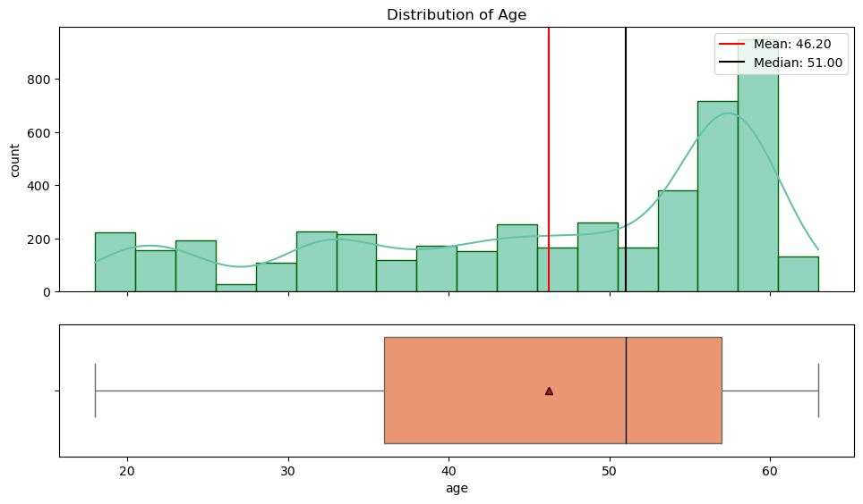

```
Mean: 46.20, Std: 13.16, Min: 18.00, Max: 63.00, Median: 51.00
```

```python
# Visualizing the distribution and identifying outliers for the 'age' feature using histogram and boxplot
feature = "age"
plot_histbox(df, feature)
```

**Observations**:

- The average age of leads is 46 years, with a range from 18 to 63 years and a median of 51 years.
- The distribution is left-skewed, indicating a tilt towards younger ages, as evidenced by the mean being less than the median.
- Despite the left skewness, there’s a significant concentration of ages in the 50 to 60 year range.
- The boxplot indicates no outliers, showing a relatively even spread within the expected age range.

#### Column | website_visits

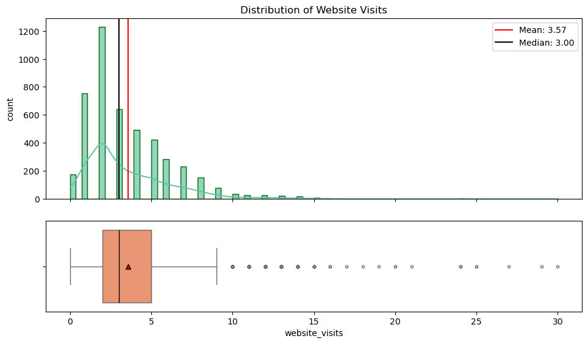

```
Mean: 3.57, Std: 2.83, Min: 0.00, Max: 30.00, Median: 3.00
```

```python
# Visualizing the distribution and identifying outliers for the 'website_visits' feature using histogram and boxplot
feature = "website_visits"
plot_histbox(df, feature)
```

```python
# Checking the number of leads that have not visited the web-site
df[df["website_visits"] == 0].shape
```

```
(174, 14)
```

**Observations**:

- The average number of website visits is approximately 4, ranging widely from 0 to 30, with a median of 3 visits.
- The distribution is highly right-skewed, indicated by a mean greater than the median.
- Most leads record a few website visits, but there is a long tail to the right, showing that a minority of leads have a high number of visits.
- The boxplot reveals several outliers beyond the whiskers, highlighting leads with an unusually high number of visits, some reaching up to 30 visits.

#### Column | time_spent_on_website

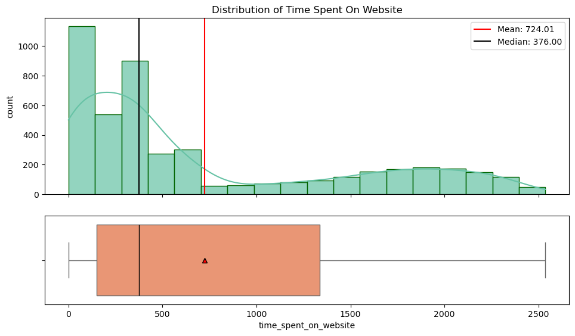

```
Mean: 724.01, Std: 743.83, Min: 0.00, Max: 2537.00, Median: 376.00
```

```python
# Visualizing the distribution and identifying outliers for the 'time_spent_on_website' feature using histogram and boxplot
feature = "time_spent_on_website"
plot_histbox(df, feature)
```

**Observations:**

- On average, leads spent 12 minutes (724 seconds) on the website, with times ranging from 0 to 42 minutes (2537 seconds) and a median of 6 minutes (376 seconds).
- The data show a highly right skewed distribution, with the mean significantly higher than the median.
- The majority of observations are clustered towards shorter visit durations on the left, but there is a long tail extending up to 42 minutes (2537 seconds).
- The absence of outliers in the boxplot indicates that even the highest values, while being on the extreme end, fall within a typical range for this dataset.

#### Column | page_views_per_visit

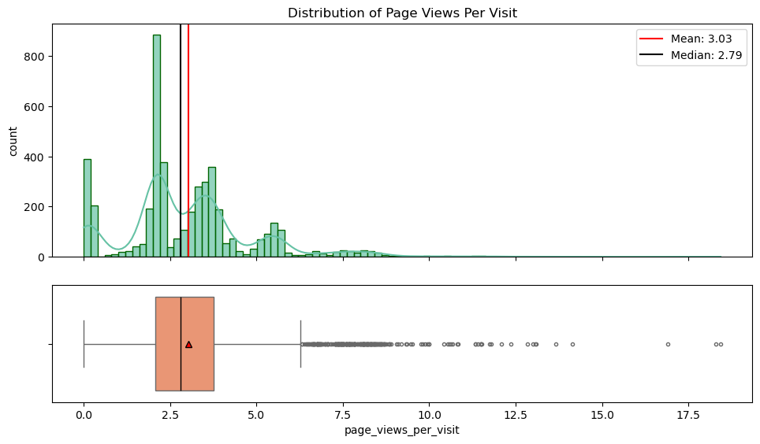

```
Mean: 3.03, Std: 1.97, Min: 0.00, Max: 18.43, Median: 2.79
```

```python
# Visualizing the distribution and identifying outliers for the 'page_views_per_visit' feature using histogram and boxplot
feature = "page_views_per_visit"
plot_histbox(df, feature)
```

**Observations**:

### Univariate Analysis of Categorical Columns

```python
# Defining a function to plot categorical variables (barplot and relative percentage annotation)
def barplot_subplots(data, features, perc=False, ytick_spacing=500):

    num_features = len(features)
    numb_cols = int(math.ceil(math.sqrt(num_features))) if num_features != 3 else 3
    numb_rows = int(math.ceil(num_features / numb_cols))

    # Adjust the height based on the number of rows
    height = 8 if numb_rows > 1 else 4

    fig, axes = plt.subplots(numb_rows, numb_cols, figsize=(10, height))
    axes = axes.flatten() if num_features > 1 else [axes]

    # Determine the maximum bar height across all features
    max_height = 0
    for feature in features:
        max_height = max(max_height, data[feature].value_counts().max())

    # Calculate appropriate tick spacing
    ytick_spacing = ytick_spacing
    upper_limit = (
        max_height // ytick_spacing + 1
    ) * ytick_spacing  # Round up to nearest tick_spacing

    for i, feature in enumerate(features):
        total = len(data[feature])
        order = data[feature].value_counts().index

        ax = axes[i]
        sns.countplot(
            data=data,
            x=feature,
            ax=ax,
            palette=palette_color,
            alpha=palette_alpha,
            order=order,
        )

        # Add title for each subplot
        formatted_title = feature.replace("_", " ").title()
        ax.set_title(formatted_title)

        # Annotate each bar by percentage or count
        for container in ax.containers:
            if perc:
                labels = [
                    f"{100 * height / total:.1f}%" for height in container.datavalues
                ]
            else:
                labels = [f"{height:.0f}" for height in container.datavalues]
            ax.bar_label(container, labels=labels, label_type="edge", fontsize=10)

            # Set y-axis limits and ticks to be consistent
            ax.set_ylim(0, upper_limit)
            ax.set_yticks(range(0, upper_limit + 1, ytick_spacing))

    # Hide any unused subplots
    for j in range(num_features, numb_rows * numb_cols):
        fig.delaxes(axes[j])

    plt.tight_layout(pad=2.0)
    plt.suptitle("Distribution of Categorical Features", y=1.01, fontsize=14)
    plt.show()
```

#### Columns | current_occupation, first_interaction, profile_completed, last_activity

```python
# Adding the numerical variable 'status' to the list of categorical columns due to its binary nature.
cat_cols.append("status")
```

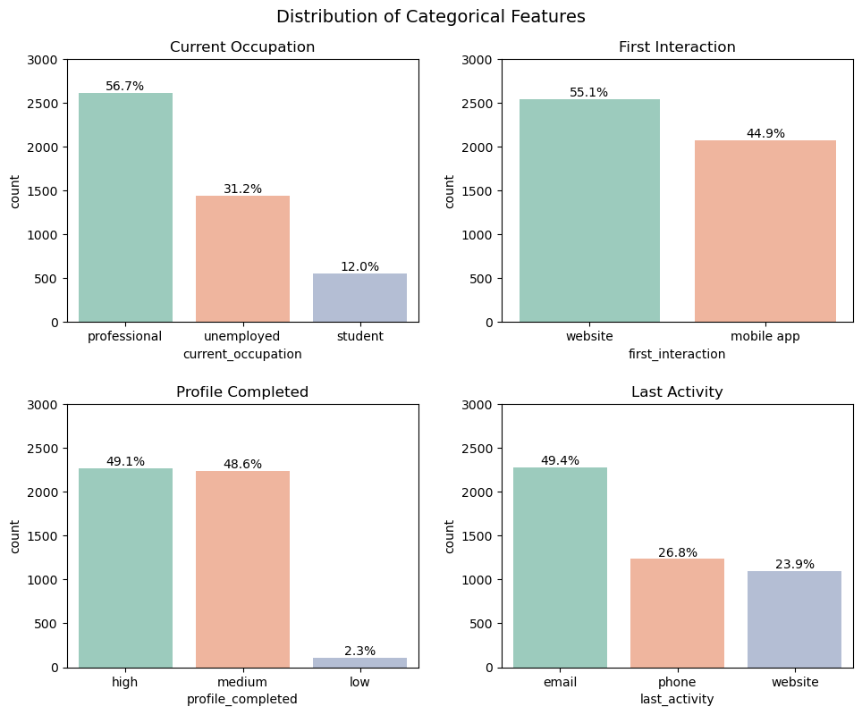

```python
# Plotting barplots for the first four categorical columns
barplot_subplots(df, cat_cols[0:4], perc=True, ytick_spacing=500)
```

**Observations**:

- The majority of leads are professionals, comprising over half of the total lead base, followed by unemployed individuals and students.
- There is a slight preference for leads to first interact through the website rather than the mobile app, though the distribution between these two modes of interaction is relatively balanced.
- Profile completion levels are nearly evenly split between high and medium, with only a small fraction of leads showing low completion rates.
- Email-related activities account for the last recorded interaction for nearly half of the leads, while phone and website interactions represent smaller but significant proportions.

#### Columns | print_media_type1, print_media_type2, digital media, educational_channels

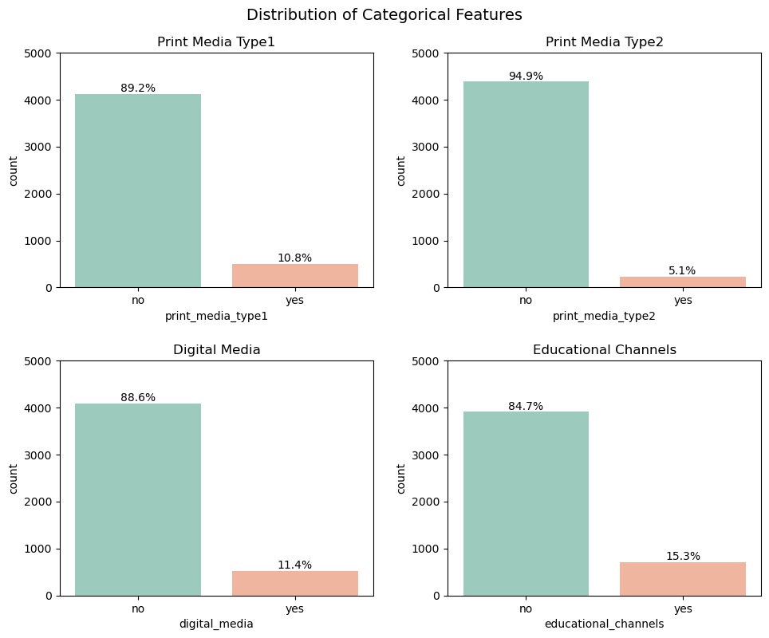

```python
# Plotting barplots for the next four categorical columns
barplot_subplots(df, cat_cols[4:8], perc=True, ytick_spacing=1000)
```

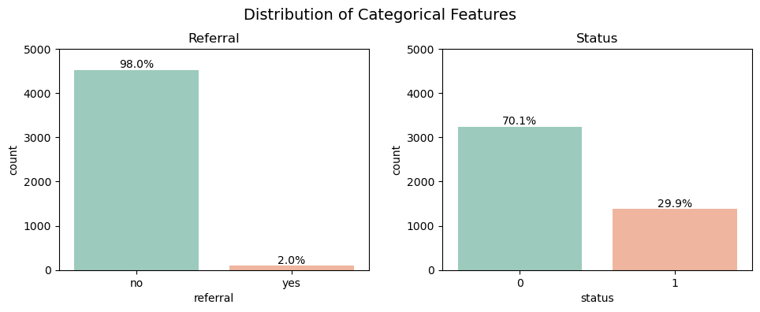

```python
# Plotting barplots for the remaining categorical columns
barplot_subplots(df, cat_cols[8::], perc=True, ytick_spacing=1000)
```

**Observations**:

- The vast majority of leads, 98.0%, were not referred by someone else, suggesting that referral strategies might be underutilized or ineffective.
- The majority of leads are non-converted, 70.1%, while only 29.9% are converted. This indicates that less than one-third of the leads convert, pointing to potential areas for improving lead nurturing and conversion tactics.

```python
# Removing the numerical variable 'status' to the list of categorical columns.
cat_cols.remove("status")
```

### Multivariate Analysis

```python
# Defining a function to calculate and print the sub-category counts
def ctable(data, predictor, feature):

    # Generate the crosstab with margins
    ctab = pd.crosstab(data[predictor], data[feature], margins=True)

    # Sort by the index to match the plot
    ctab = ctab.sort_index()

    # Print the crosstab
    print("-" * 40)
    print(ctab)
    print("-" * 40)
```

```python
# Defining a function to plot categorical variables (stacked barplot, crosstab and relative percentage annotation)
def stacked_barplot(data, predictor, feature):

    # Generate the crosstab for plotting
    ctable(data, predictor, feature)

    # Create the crosstab normalized by row ('index')
    ctab = pd.crosstab(data[predictor], data[feature], normalize="index") * 100

    # Sort crosstab by the index to ensure order consistency
    ctab = ctab.sort_index()

    # Plotting the crosstab as a stacked bar plot
    ax = ctab.plot(
        kind="bar",
        stacked=True,
        rot=0,
        figsize=(10, 6),
        color=palette_color,
        alpha=palette_alpha,
    )

    # Adjust the legend position
    ax.legend(title="status", bbox_to_anchor=(0.92, 0.98), loc="upper left")

    # Annotate each bar by percentage
    for container in ax.containers:
        ax.bar_label(container, fmt="%.1f%%", label_type="center", fontsize=10)

    # Add title for each subplot
    formatted_predictor = predictor.replace("_", " ").title()
    formatted_feature = feature.replace("_", " ").title()

    plt.title(f"Distribution of {formatted_predictor} by {formatted_feature}")
    plt.ylabel("percentage")
    plt.xlabel(predictor)
    plt.tight_layout(pad=2.0)
    plt.show()
```

```python
# Defining a function to create a boxplot (with statistical analysis)
def boxplot_stats(data, predictor, target):

    stat = (
        data.groupby([predictor])[target]
        .describe()
        .round(2)
        .sort_values(by=("mean"), ascending=False)
    )
    print("-" * 80)
    print(stat)
    print("-" * 80)

    meanprops = {"markerfacecolor": "red", "markeredgecolor": "black"}

    plt.figure(figsize=(10, 6))
    sns.boxplot(
        data=data,
        y=predictor,
        x=target,
        showmeans=True,
        meanprops=meanprops,
        hue=predictor,
        palette=palette_color,
    )

    # Add title for each subplot
    formatted_predictor = predictor.replace("_", " ").title()
    formatted_target = target.replace("_", " ").title()

    plt.title(f"Distribution of {formatted_predictor} by {formatted_target}")
    plt.tight_layout(pad=2.0)
    plt.show()
```

```python
# Defining a function to plot distributiona and boxplot with respect to target variable (binary)
def distplot_boxplot_target(
    df, predictor, target, figsize=(10, 10), kde=True, hratio=(1, 1.5, 1.5)
):

    # Create a subplot layout with 1 big plot on top and 2 smaller plots below
    plt.figure(figsize=figsize)
    gs = gridspec.GridSpec(3, 2, height_ratios=hratio)

    # Initialization
    axes = []  # Empty list to store axes
    stats_summary = {}  # Dictionary to store statistics for each target category
    meanprops = {"markerfacecolor": "red", "markeredgecolor": "black"}

    # Extract unique target values
    target_uniq = sorted(df[target].unique())

    # Boxplot
    ax1 = plt.subplot(gs[0, :])
    sns.boxplot(
        data=df,
        x=target,
        y=predictor,
        showmeans=True,
        meanprops=meanprops,
        palette=palette_color,
        ax=ax1,
    )

    # Add title for each subplot
    formatted_predictor = predictor.replace("_", " ").title()
    formatted_target = target.replace("_", " ").title()
    ax1.set_title((f"Distribution of {formatted_predictor} by {formatted_target}"))
    axes.append(ax1)

    # Histplots
    for i, tvalue in enumerate(target_uniq):
        df_temp = df[df[target] == tvalue]

        # Calculate key statistics
        mean_val = df_temp[predictor].mean()
        median_val = df_temp[predictor].median()
        skew = df_temp[predictor].skew()

        # Store the statistics for printing
        stats_summary[tvalue] = {
            "mean": mean_val,
            "median": median_val,
            "skewness": skew,
        }

        ax = plt.subplot(gs[1, i])
        sns.histplot(data=df_temp, kde=kde, x=predictor, color=palette_color[i], ax=ax)
        ax.set_title(f"{target} = [{tvalue}]")
        ax.set_xlabel(predictor)
        ax.set_ylabel("count")

        # Add lines for mean and median values
        ax.axvline(
            mean_val,
            color="red",
            linestyle="-",
            linewidth=1.5,
            label=f"Mean: {mean_val:.2f}",
        )
        ax.axvline(
            median_val,
            color="black",
            linestyle="-",
            linewidth=1.5,
            label=f"Median: {median_val:.2f}",
        )
        ax.legend()
        axes.append(ax)

    # Adjust layout
    plt.tight_layout(pad=2.0)
    plt.show()

    # Print the key statistics for each target category
    for tvalue, stats in stats_summary.items():
        stats_str = ", ".join(
            [f"{key.capitalize()}: {value:.2f}" for key, value in stats.items()]
        )
        print(f"{target} = [{tvalue}] | {stats_str}")
```

#### Columns | age, website_visits, time_spent_on_website, page_views_per_visit, status

```python
# Select relevant features
relevant_features = num_cols[:]

# Calculate correlation matrix for numerical features
corr = df[relevant_features].corr().round(2)

# Convert the correlation matrix into a DataFrame and rename the 'index' colum
corr_df = corr.reset_index().rename(columns={"index": "numerical_feature"})

# Display the correlation matrix
display(corr_df)
```

|  | numerical_feature | age | website_visits | time_spent_on_website | page_views_per_visit | status |
| --- | --- | --- | --- | --- | --- | --- |
| 0 | age | 1.00 | -0.01 | 0.02 | -0.04 | 0.12 |
| 1 | website_visits | -0.01 | 1.00 | 0.06 | 0.07 | -0.01 |
| 2 | time_spent_on_website | 0.02 | 0.06 | 1.00 | 0.07 | 0.30 |
| 3 | page_views_per_visit | -0.04 | 0.07 | 0.07 | 1.00 | 0.00 |
| 4 | status | 0.12 | -0.01 | 0.30 | 0.00 | 1.00 |

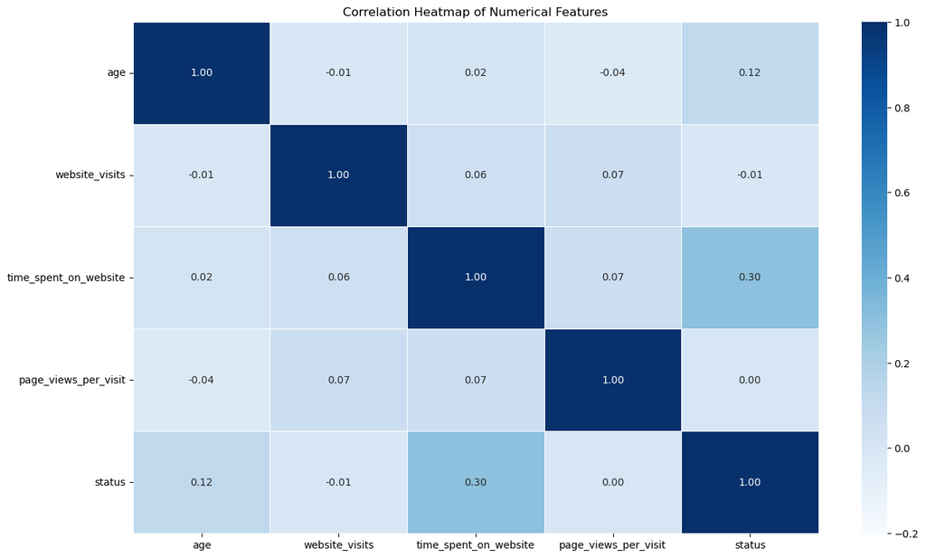

```python
# Plot the correlation heatmap
plt.figure(figsize=(14, 8))
sns.heatmap(data=corr, annot=True, linewidths=0.5, fmt=".2f", vmin=-0.2, cmap="Blues")

# Add title
plt.title("Correlation Heatmap of Numerical Features")
plt.tight_layout(pad=2.0)
plt.show()
```

- Most features have weak or no significant correlations with each other, as indicated by the correlation values close to 0.
- Weak positive correlation, 0.12, between **age** and **status**, suggesting that older leads are slightly more likely to be converted to paid customers.
- Moderate positive correlation, 0.30, between **time_spent_on_website** and **status**, indicating that leads who spend more time on the website are more likely to be converted to paid customers.

#### Columns | current_occupation vs. status

```
----------------------------------------
status                 0     1   All
current_occupation
All                 3235  1377  4612
professional        1687   929  2616
student              490    65   555
unemployed          1058   383  1441
----------------------------------------
```

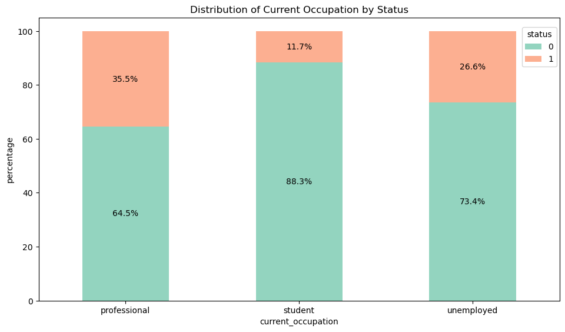

```python
stacked_barplot(df, "current_occupation", "status")
```

**Observations**:

- The stacked bar plot clearly shows that the current occupation plays a significant role in lead engagement and conversion rates.
- Professionals have the highest conversion rate at 35.5%, followed by unemployed at 26.6%, while students have the lowest conversion rate at 11.7%.
- The lower conversion rate among students suggests that different engagement strategies might be needed for this group.

#### Columns | current_occupation vs. age

```
--------------------------------------------------------------------------------
                     count   mean    std   min   25%   50%   75%   max
current_occupation
unemployed          1441.0  50.14  10.00  32.0  42.0  54.0  58.0  63.0
professional        2616.0  49.35   9.89  25.0  42.0  54.0  57.0  60.0
student              555.0  21.14   2.00  18.0  19.0  21.0  23.0  25.0
--------------------------------------------------------------------------------
```

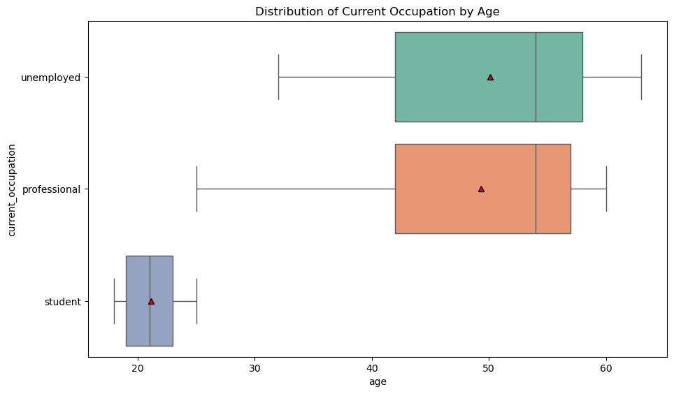

```python
boxplot_stats(df, "current_occupation", "age")
```

**Observations**:

- The box plot and statistical summary provide a clear view of the age distributions across different occupation categories.
- Unemployed leads typically center around a median age of 54 years, with most falling between 42 and 58 years.
- Professional leads also show a median age of 54 years, indicating a predominance of a mature age group, similar to unemployed leads.
- Student leads are considerably younger, with their ages tightly clustered around 21 years.
- Both unemployed and professional leads share a mature age profile, with median ages around 54 years and comparable interquartile ranges, suggesting similar age distributions. In contrast, student leads demonstrate a distinctly younger demographic, primarily concentrated in the early twenties.

#### Columns | first_interaction vs. status

```
----------------------------------------
status                0     1   All
first_interaction
All                3235  1377  4612
mobile app         1852   218  2070
website            1383  1159  2542
----------------------------------------
```

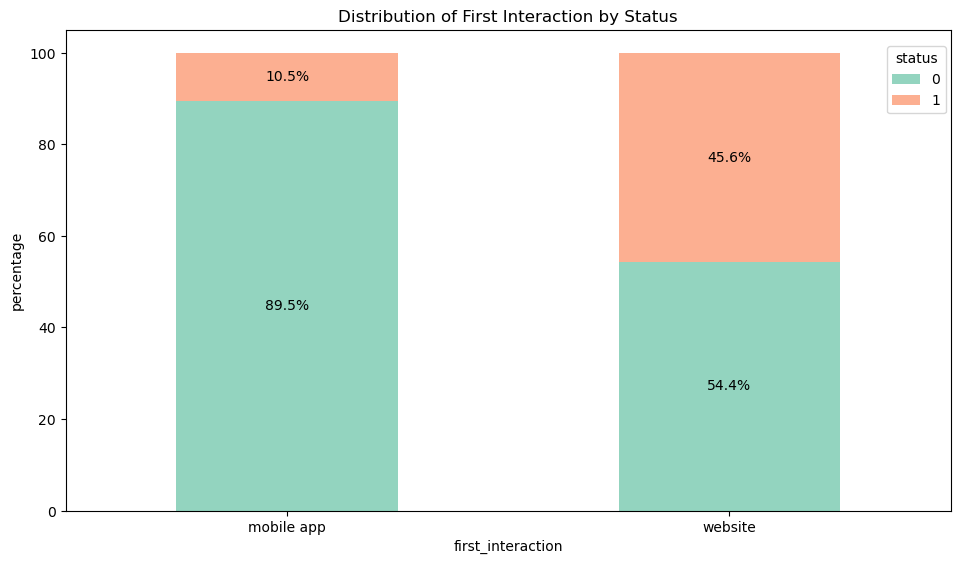

```python
stacked_barplot(df, "first_interaction", "status")
```

**Observations**:

- The stacked bar plot clearly shows that the channel of first interaction plays a significant role in lead engagement and conversion rates.
- Leads whose first interaction was via the website show a much higher conversion rate at 45.6% compared to 10.5% for those whose first interaction was via the mobile app.
- The high conversion rate of the website suggests that this channel is a more engaging and potentially more informative platform for initial interactions.

#### Columns | profile_completed vs. status

```
----------------------------------------
status                0     1   All
profile_completed
All                3235  1377  4612
high               1318   946  2264
low                  99     8   107
medium             1818   423  2241
----------------------------------------
```

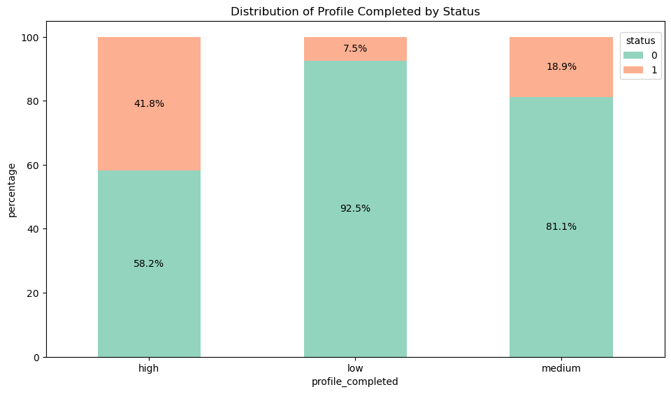

```python
stacked_barplot(df, "profile_completed", "status")
```

**Observations**:

- The stacked bar plot clearly demonstrates the strong correlation between profile completion levels and lead conversion rates.
- Leads with a high profile completion rate have the highest conversion rate at 41.8%, followed by those with a medium profile completion rate at 18.9%, while those with a low profile completion rate have the lowest conversion rate at 7.5%.
- Higher profile completion rates are significantly correlated with higher conversion rates, suggesting that encouraging leads to complete their profiles could be an effective strategy for improving engagement and conversion.

#### Columns | last_activity vs. status

```
----------------------------------------
status            0     1   All
last_activity
All            3235  1377  4612
email          1587   691  2278
phone           971   263  1234
website         677   423  1100
----------------------------------------
```

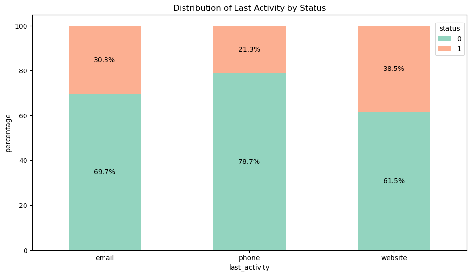

```python
stacked_barplot(df, "last_activity", "status")
```

**Observations**:

- The stacked bar plot demonstrates that the type of last activity significantly influences lead conversion rates.
- Leads whose last activity was website-related have the highest conversion rate at 38.5%, followed by those with email activity at 30.3%, while leads with phone activity have the lowest conversion rate at 21.3%.
- Recent website activity is highly correlated with higher conversion rates, suggesting that maintaining an active presence on the website could be an effective strategy for improving engagement and conversion.

#### Column | age vs. status

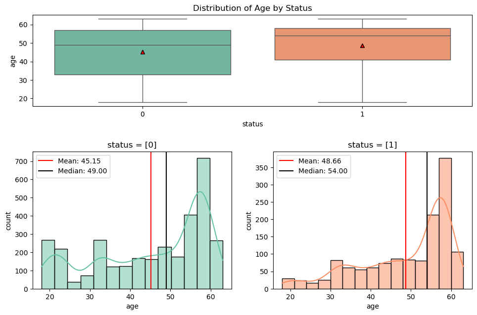

```
status = [0] | Mean: 45.15, Median: 49.00, Skewness: -0.60
status = [1] | Mean: 48.66, Median: 54.00, Skewness: -0.95
```

```python
distplot_boxplot_target(df, "age", "status")
```

**Observations**:

- Both distributions of age for leads are left-skewed. The distribution for non-converted leads is multimodal, showing peaks at both younger and older ages, while the distribution for converted leads is single-peaked with a high concentration at older ages.
- There are no significant outliers in either distribution, indicating consistent age ranges within each status group.
- Converted leads tend to be older, as evidenced by higher mean and median ages, suggesting that age is a significant factor in lead conversion.
- This suggests that targeting older leads could be beneficial for improving conversion rates.

#### Columns | website_visits vs. status

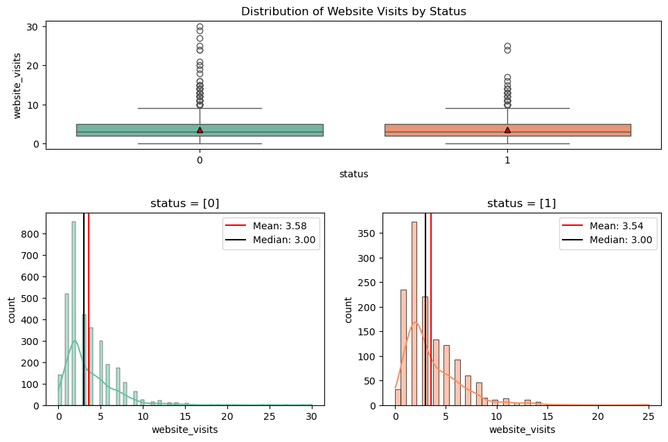

```
status = [0] | Mean: 3.58, Median: 3.00, Skewness: 2.22
status = [1] | Mean: 3.54, Median: 3.00, Skewness: 1.98
```

```python
distplot_boxplot_target(df, "website_visits", "status")
```

#### Columns | time_spent_on_website vs. status

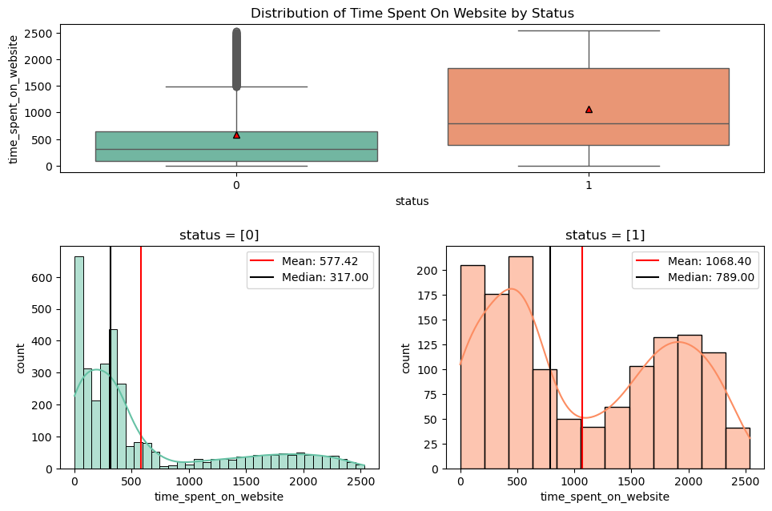

```
status = [0] | Mean: 577.42, Median: 317.00, Skewness: 1.40
status = [1] | Mean: 1068.40, Median: 789.00, Skewness: 0.23
```

```python
distplot_boxplot_target(df, "time_spent_on_website", "status")
```

**Observation**:

- The distribution of time spent on the website for non-converted leads is right-skewed with many outliers, indicating a few leads with very high engagement.
- The distribution for converted leads is right-skewed and bimodal, with concentrations of observations around the 8-minute (500s) and 30-minute (1800s) marks.
- Converted leads tend to spend significantly more time on the website compared to non-converted leads, as indicated by higher medians and means.
- This suggests that extended and consistent browsing is a strong indicator of higher engagement and potential conversion.

#### Columns | page_views_per_visit vs. status

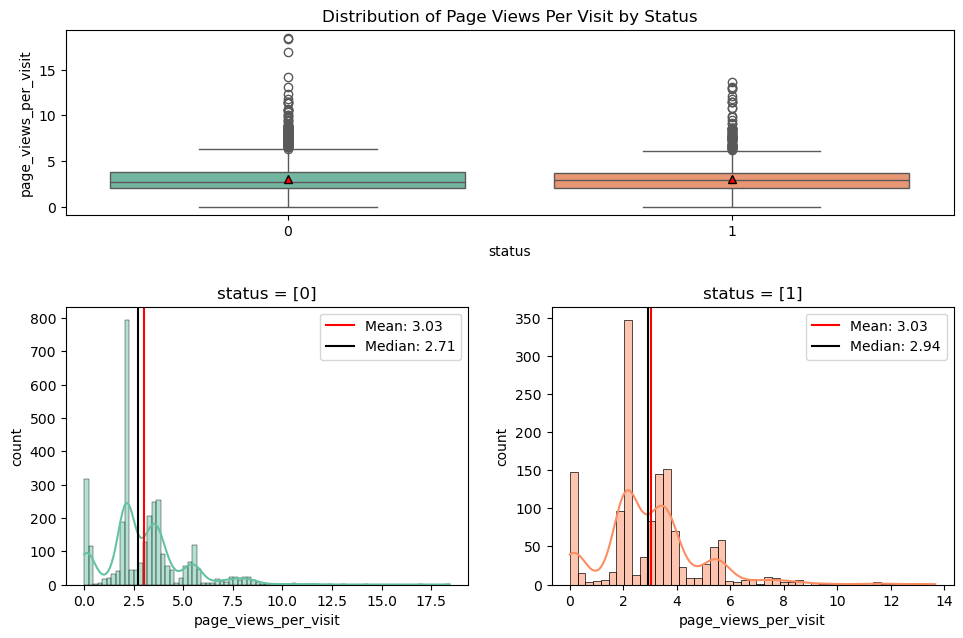

```
status = [0] | Mean: 3.03, Median: 2.71, Skewness: 1.26
status = [1] | Mean: 3.03, Median: 2.94, Skewness: 1.29
```

```python
distplot_boxplot_target(df, "page_views_per_visit", "status")
```

**Observations**:

#### Columns | print_media_type1 vs. status

```
----------------------------------------
status                0     1   All
print_media_type1
All                3235  1377  4612
no                 2897  1218  4115
yes                 338   159   497
----------------------------------------
```

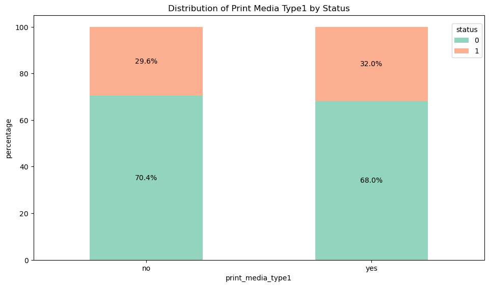

```python
stacked_barplot(df, "print_media_type1", "status")
```

**Observations**:

- Exposure to print media type 1 appears to have a marginally positive effect on lead engagement and conversion rates.
- In numbers, leads exposed to print media type 1 show a slightly higher conversion rate of 32.0% compared to 29.6% for those not exposed.

#### Columns | print_media_type2 vs. status

```
----------------------------------------
status                0     1   All
print_media_type2
All                3235  1377  4612
no                 3077  1302  4379
yes                 158    75   233
----------------------------------------
```

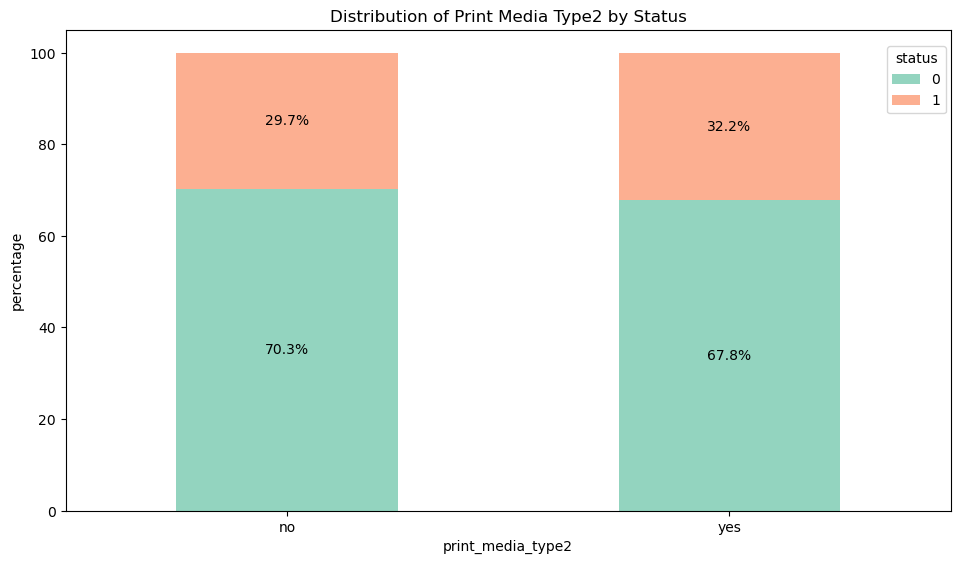

```python
stacked_barplot(df, "print_media_type2", "status")
```

**Observations**:

- Exposure to print media type 2 appears to have a marginally positive effect on lead engagement and conversion rates.
- In numbers, leads exposed to print media type 2 show a slightly higher conversion rate of 32.2% compared to 29.7% for those not exposed.
- This outcome mirrors that of print media type 1, where exposure similarly results in a marginally higher conversion rate.

#### Columns | digital_media vs. status

```
----------------------------------------
status            0     1   All
digital_media
All            3235  1377  4612
no             2876  1209  4085
yes             359   168   527
----------------------------------------
```

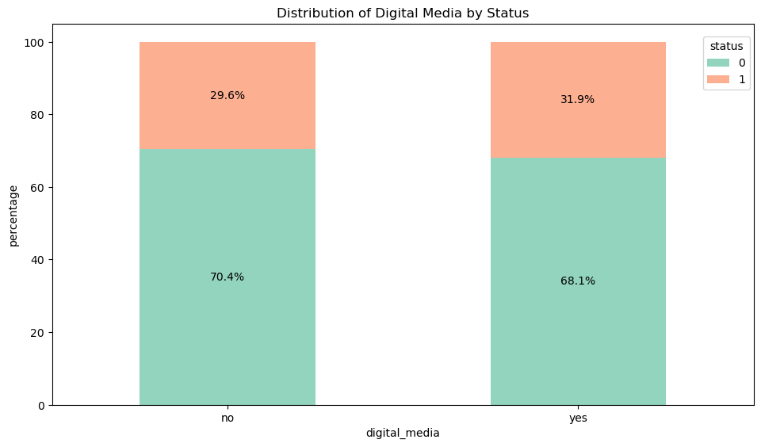

```python
stacked_barplot(df, "digital_media", "status")
```

**Observations**:

- Exposure to digital media appears to have a marginally positive effect on lead engagement and conversion rates.
- In numbers, leads exposed to digital media show a slightly higher conversion rate of 31.9% compared to 29.6% for those not exposed.
- This outcome mirrors that of print media type 1 and 2, where exposure similarly results in a marginally higher conversion rate.

#### Columns | educational_channels vs. status

```
----------------------------------------
status                   0     1   All
educational_channels
All                   3235  1377  4612
no                    2727  1180  3907
yes                    508   197   705
----------------------------------------
```

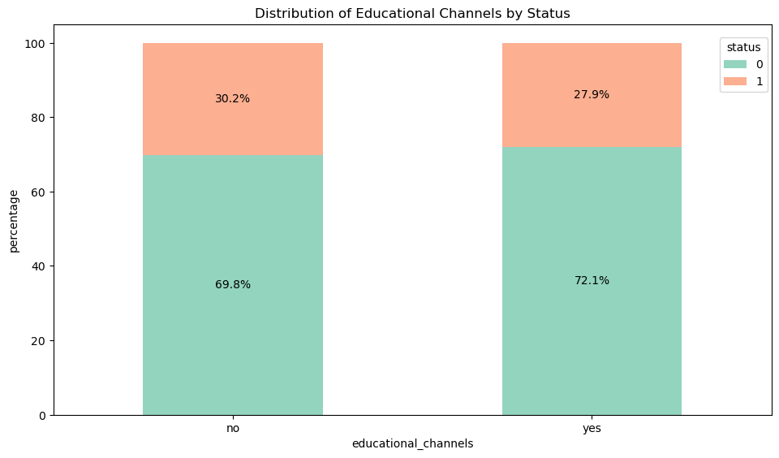

```python
stacked_barplot(df, "educational_channels", "status")
```

#### Columns | referral vs. status

```
----------------------------------------
status       0     1   All
referral
All       3235  1377  4612
no        3205  1314  4519
yes         30    63    93
----------------------------------------
```

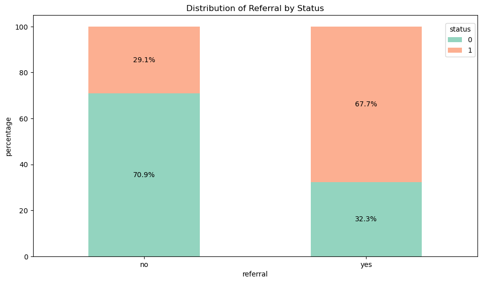

```python
stacked_barplot(df, "referral", "status")
```

**Observations**:

- Referrals appear to have a strongly positive effect on lead conversion rates.
- In numbers, leads who received referrals show a much higher conversion rate of 67.7% compared to 29.1% for those who did not.
- This suggests that leveraging referral programs could be highly effective for engagement and lead conversion strategies.

### Outlier Analysis

```python
# Selecte numerical variables
num_data = df[num_cols].drop(columns=["status"])

# Calculate quartiles and IQR
Q1 = num_data.quantile(0.25)
Q3 = num_data.quantile(0.75)
IQR = Q3 - Q1

# Find lower and upper bounds for outliers
lower = Q1 - 1.5 * IQR
upper = Q3 + 1.5 * IQR
```

```
Outliers | Out of Bounds Percentage
----------------------------------------
age                      0.00
website_visits           3.34
time_spent_on_website    0.00
page_views_per_visit     5.57
dtype: float64
----------------------------------------
```

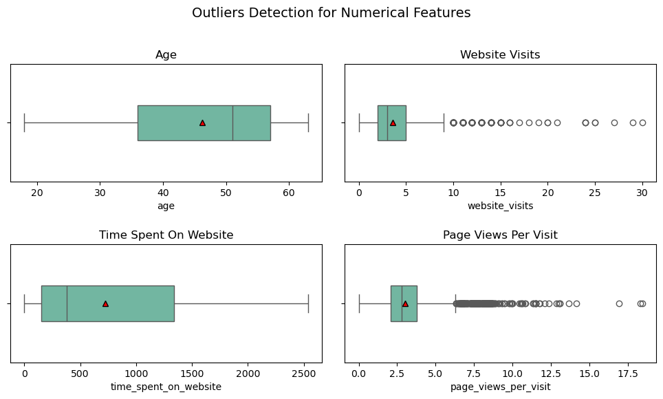

```python
# Calculate the percentage of outliers for each numerical variable
out_of_bounds_percentage = ((num_data < lower) | (num_data > upper)).mean() * 100
print("Outliers | Out of Bounds Percentage")
print("-" * 40)
print(out_of_bounds_percentage.round(2))
print("-" * 40)

# Set figure size
plt.figure(figsize=(10, 6))

# Properties for mean marker
meanprops = {"markerfacecolor": "red", "markeredgecolor": "black"}
color_hist = [palette_color[0], palette_color[1]]

# Calculate the number of rows and columns for subplots
numb_cols = 2
numb_rows = int(np.ceil(len(num_data.columns) / numb_cols))

# Loop through each numeric column and create a subplot
for i, variable in enumerate(num_data.columns):
    plt.subplot(numb_rows, numb_cols, i + 1)
    sns.boxplot(
        data=df,
        x=variable,
        showmeans=True,
        meanprops=meanprops,
        palette=color_hist,
        width=0.3,
    )
    # Add title for each subplot
    formatted_title = variable.replace("_", " ").title()
    plt.title(formatted_title)

# Add title for the entire plot
plt.suptitle("Outliers Detection for Numerical Features", y=0.98, fontsize=14)

# Adjust layout and show plot
plt.tight_layout(pad=2.0)
plt.show()
```

**Observations**:

These outliers likely reflect genuine behavior patterns of highly engaged leads. They represent real scenarios of lead behavior and engagement, indicating a lead’s strong interest or need for extensive information before making a decision. The ML models should learn those underlying pattern as well.

- **age, time_spent_on_website**: No outliers present, indicating that both metrics of leads fall within a consistent range without extreme values.
- **website_visits**: Approximately 3.34% of the data points are outliers, indicating a small proportion of leads with unusually high numbers of website visits.
- **page_views_per_visit**: Around 5.57% of the data points are outliers, showing that a notable fraction of leads view significantly more pages per visit.

## Key Insights

- **Impact of Current Occupation**

  Leads’ current occupations significantly influence conversion rates. Professionals have the highest conversion rate at 35.5%, followed by unemployed individuals at 26.6%, while students trail at 11.7%. Tailored engagement strategies are needed to address the distinct expectations and behavior of each group, particularly students.
- **Effect of First Interaction Channel**

  The first interaction channel plays a critical role in engagement and conversion. Leads interacting via the website have a conversion rate of 45.6%, substantially outperforming mobile app interactions at 10.5%. This underscores the website’s effectiveness as a primary platform for initial engagement and information delivery.
- **Most Effective Interaction Mode**

  Among interaction modes, website-related activities achieve the highest conversion rate at 38.5%, followed by email activities at 30.3%. Phone interactions are less effective, with a conversion rate of 21.3%. This highlights the importance of prioritizing website engagement to drive conversions.
- **Performance of Lead Channels**

  Referrals are the most effective lead channel, achieving a conversion rate of 67.7%, far surpassing other sources. However, referrals account for a minimal percentage of total lead conversions, indicating an underutilized opportunity. Print and digital media, along with educational channels, show relatively lower effectiveness, with conversion rates ranging from 28% to 33%.
- **Influence of Profile Completion**

  Profile completion levels are strongly correlated with conversion rates. Leads with highly completed profiles convert at 41.8%, compared to 18.9% for medium and 7.5% for low completion levels. Encouraging detailed profile completion presents a significant opportunity to enhance lead engagement and conversion.

## Model Preparation and Setup

This section outlines the model preparation process, including handling a class imbalance in the target variable through stratified sampling to preserve class distributions across train and validation sets. Minor outliers are retained as they reflect real-world behavior, and no missing values were identified, ensuring the dataset is ready for modeling.

**Model Evaluation**

The model’s performance is assessed using a classification report, which highlights metrics such as precision, recall, F1-score, and support for each class. This provides a comprehensive understanding of the model’s accuracy and its ability to balance false positives and false negatives effectively.

**Model Optimization**

To minimize false negatives (Type II Errors) and prevent losing potential customers—a critical business priority—the model is optimized to maximize Recall. By focusing on high-potential leads, this approach balances resource allocation with customer acquisition:

- **Type I Error**: Predicting a lead will convert when it doesn’t, leading to wasted resources.
- **Type II Error**: Predicting a lead won’t convert when it does, resulting in lost customers.

### Data Preprocessing

```python
# Separating the dependent (target) variable and independent variables
X = df.drop(columns=["status"], axis=1)
Y = df["status"]
print(X.shape, Y.shape)
```

```
(4612, 13) (4612,)
```

### Encoding of Categorical Variables

```python
# Creating list of dummy columns (categorical features)
to_get_dummies_for = cat_cols

# Creating dummy variables
X = pd.get_dummies(data=X, columns=to_get_dummies_for, drop_first=True)

# Ensure the target variable is also encoded if it's categorical
if Y.dtype == "object":
    Y = pd.get_dummies(Y, drop_first=True)

# Display the dimensions of the dataset
print(X.shape)
```

```
(4612, 16)
```

```python
# Checking the encoded dataset
X.head()
```

|  | age | website_visits | time_spent_on_website | page_views_per_visit | current_occupation_student | current_occupation_unemployed | first_interaction_website | profile_completed_low | profile_completed_medium | last_activity_phone | last_activity_website | print_media_type1_yes | print_media_type2_yes | digital_media_yes | educational_channels_yes | referral_yes |
| --- | --- | --- | --- | --- | --- | --- | --- | --- | --- | --- | --- | --- | --- | --- | --- | --- |
| 0 | 57 | 7 | 1639 | 1.861 | False | True | True | False | False | False | True | True | False | True | False | False |
| 1 | 56 | 2 | 83 | 0.320 | False | False | False | False | True | False | True | False | False | False | True | False |
| 2 | 52 | 3 | 330 | 0.074 | False | False | True | False | True | False | True | False | False | True | False | False |
| 3 | 53 | 4 | 464 | 2.057 | False | True | True | False | False | False | True | False | False | False | False | False |
| 4 | 23 | 4 | 600 | 16.914 | True | False | True | False | False | False | False | False | False | False | False | False |

### Splitting the Data

```python
# Splitting the data (70:30 ratio) with stratification
X_train, X_test, y_train, y_test = train_test_split(
    X, Y, test_size=0.3, random_state=1, stratify=Y
)
```

```python
# Assuming y_train and y_test are defined
y_train_distribution = y_train.value_counts(normalize=True).round(3)
y_test_distribution = y_test.value_counts(normalize=True).round(3)

# Combine the distributions into a single data frame
distribution_df = pd.DataFrame(
    {"Training": y_train_distribution, "Testing": y_test_distribution}
)

print("Target Distribution")
print("-" * 40)
print(distribution_df)
```

```
Target Distribution
----------------------------------------
        Training  Testing
status
0          0.701    0.702
1          0.299    0.298
```

### Model Evaluation

```python
# Function to print the classification report and calculate the confusion matrix
def metrics_score(actual, predicted):
    print(classification_report(actual, predicted))

    cm = confusion_matrix(actual, predicted)

    cn_labels = ["Not Converted", "Converted"]

    plt.figure(figsize=(10, 6))
    ax = sns.heatmap(
        cm,
        annot=True,
        linewidths=0.5,
        fmt=".2f",
        vmin=0,
        vmax=np.max(cm) * 1.2,
        cmap="Blues",
        xticklabels=cn_labels,
        yticklabels=cn_labels,
    )

    # Convert axis labels to lowercase
    ax.set_xticklabels([label.get_text().lower() for label in ax.get_xticklabels()])
    ax.set_yticklabels([label.get_text().lower() for label in ax.get_yticklabels()])

    plt.ylabel("Actual")
    plt.xlabel("Predicted")
    plt.title("Confusion Matrix")
    plt.tight_layout(pad=2.0)
    plt.show()

    # Calculate and return metrics, rounded to 3 decimal places and converted floats
    metrics = {
        "accuracy": round(float(accuracy_score(actual, predicted)), 3),
        "precision": round(float(precision_score(actual, predicted, pos_label=1)), 3),
        "recall": round(float(recall_score(actual, predicted, pos_label=1)), 3),
        "f1_score": round(float(f1_score(actual, predicted, pos_label=1)), 3),
    }
    return metrics
```

## Model 1: Logistic Regression

### Building Logistic Regression Model

```python
# Standardizing the numerical features
scaler = StandardScaler()
X_train_scaled = scaler.fit_transform(X_train)
X_test_scaled = scaler.transform(X_test)
```

```python
# Building a Logistic Regression model
model_lr = LogisticRegression(random_state=1, max_iter=1000)

# Fitting the model on the training data
model_lr.fit(X_train_scaled, y_train)
```

```
LogisticRegression(max_iter=1000, random_state=1)
```

### Evaluating Model Performance

```
Training Performance:
              precision    recall  f1-score   support

           0       0.85      0.90      0.88      2264
           1       0.73      0.64      0.68       964

    accuracy                           0.82      3228
   macro avg       0.79      0.77      0.78      3228
weighted avg       0.82      0.82      0.82      3228
```

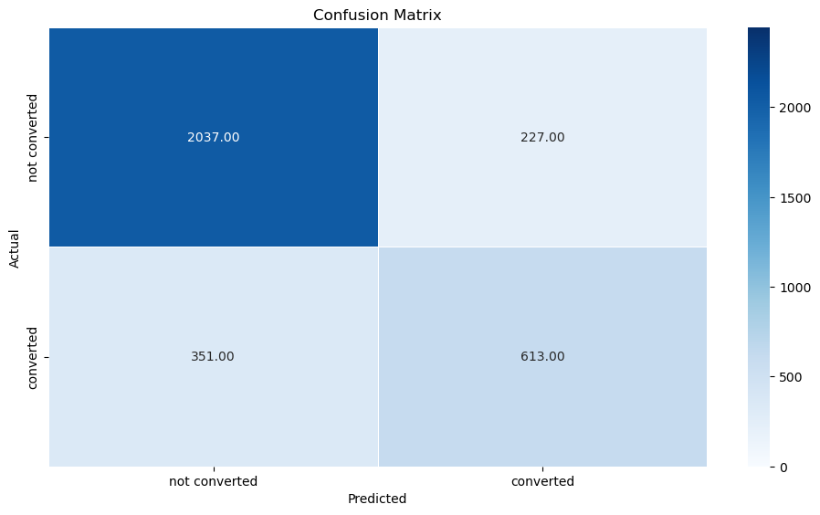

```
Testing Performance:
              precision    recall  f1-score   support

           0       0.85      0.91      0.88       971
           1       0.75      0.63      0.69       413

    accuracy                           0.83      1384
   macro avg       0.80      0.77      0.78      1384
weighted avg       0.82      0.83      0.82      1384
```

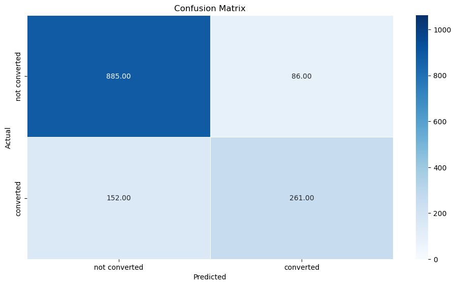

```python
# Predicting on the training and testing data
y_train_pred_lr = model_lr.predict(X_train_scaled)
y_test_pred_lr = model_lr.predict(X_test_scaled)

# Evaluating the model on the training data
print("Training Performance:")

model_lr_train_metrics = metrics_score(y_train, y_train_pred_lr)

# Evaluating the model on the testing data
print("Testing Performance:")
model_lr_test_metrics = metrics_score(y_test, y_test_pred_lr)
```

**Observations**:

- **Train Dataset**: The logistic regression model achieves an accuracy of 0.82, with a precision of 0.73 and recall of 0.64 for the converted class. The confusion matrix shows 351 false negatives and 227 false positives, highlighting the model’s challenges in correctly identifying converted leads.
- **Test Dataset**: The model performs consistently on the test dataset, achieving an accuracy of 0.83, with a precision of 0.75 and recall of 0.63 for the converted class. The confusion matrix reveals 152 false negatives and 86 false positives, emphasizing its limitations in predicting converted leads effectively.
- **Hyperparameter Tuning**: Strategies like adjusting class weights, employing L1/L2 regularization, or utilizing oversampling techniques such as SMOTE could enhance recall and reduce false negatives, improving the model’s ability to meet the business objective of prioritizing lead identification.

### Hyperparameter Tuning

The imbalance in the target variable is addressed by setting the class_weight hyperparameter to {0: 0.3, 1: 0.7}, ensuring higher importance is placed on converted leads (class 1) during model training. Hyperparameter tuning is performed using GridSearchCV to optimize the logistic regression model’s performance by identifying the best parameter combinations:

- **C**: Controls the regularization strength, balancing the trade-off between model complexity and generalization. Smaller values indicate stronger regularization.
- **penalty**: Specifies the type of regularization applied, such as l1 (Lasso) for feature selection or l2 (Ridge) to prevent overfitting.
- **solver**: Determines the optimization algorithm used for training, with options like saga for larger datasets or liblinear for smaller datasets and specific regularization types.

```python
# Building a Logistic Regression model
model_lr_tuned = LogisticRegression(
    random_state=1, max_iter=1000, class_weight={0: 0.3, 1: 0.70}
)
```

```python
# Define the parameter grid for logistic regression
param_grid_lr = {
    "C": [0.05, 0.1, 0.5, 1, 10, 100],
    "penalty": ["l1", "l2"],
    "solver": ["saga", "liblinear"],
}

# Initialize and run the grid search with cross-validation
gs_lr = GridSearchCV(model_lr_tuned, param_grid_lr, scoring="recall", cv=6, n_jobs=-1)
gs_lr = gs_lr.fit(X_train_scaled, y_train)

# Get the best parameters and best score
best_params_lr = gs_lr.best_params_
best_score_lr = gs_lr.best_score_

print(f"Best Parameters: {best_params_lr}")
print(f"Best Recall Score: {best_score_lr:.4f}")
```

```
Best Parameters: {'C': 0.05, 'penalty': 'l1', 'solver': 'liblinear'}
Best Recall Score: 0.8402
```

```python
# Update the classifier with the best found parameters
model_lr_tuned = gs_lr.best_estimator_

# Fit the tuned model on the training data
model_lr_tuned.fit(X_train_scaled, y_train)
```

```
LogisticRegression(C=0.05, class_weight={0: 0.3, 1: 0.7}, max_iter=1000,
                   penalty='l1', random_state=1, solver='liblinear')
```

### Evaluating Model Performance

```
Training Performance with Best Estimator:
              precision    recall  f1-score   support

           0       0.92      0.77      0.83      2264
           1       0.60      0.84      0.70       964

    accuracy                           0.79      3228
   macro avg       0.76      0.80      0.77      3228
weighted avg       0.82      0.79      0.79      3228
```

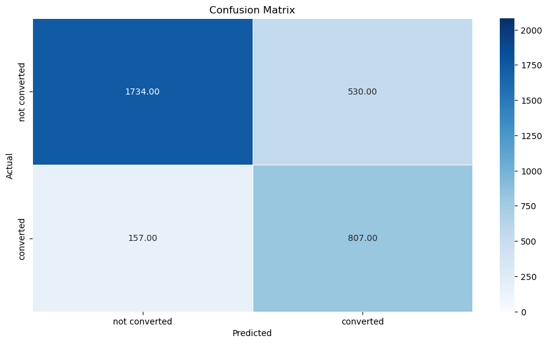

```
Testing Performance with Best Estimator:
              precision    recall  f1-score   support

           0       0.93      0.78      0.84       971
           1       0.62      0.85      0.72       413

    accuracy                           0.80      1384
   macro avg       0.77      0.81      0.78      1384
weighted avg       0.83      0.80      0.81      1384
```

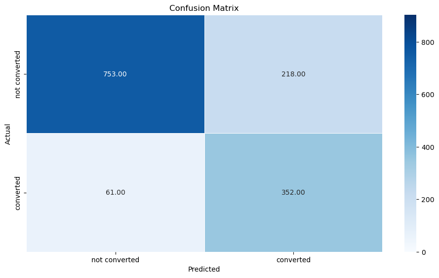

```python
# Predict on the training and testing data using the best estimator
y_train_pred_lr_tuned = model_lr_tuned.predict(X_train_scaled)
y_test_pred_lr_tuned = model_lr_tuned.predict(X_test_scaled)

# Evaluate the model on the training data
print("Training Performance with Best Estimator:")
model_lr_tuned_train_metrics = metrics_score(y_train, y_train_pred_lr_tuned)

# Evaluate the model on the testing data
print("Testing Performance with Best Estimator:")
model_lr_tuned_test_metrics = metrics_score(y_test, y_test_pred_lr_tuned)
```

**Observations**:

- **Train Dataset**: Accuracy decreases from 0.82 to 0.79, reflecting a trade-off for better recall optimization. Recall improves significantly from 0.64 to 0.84, reducing false negatives from 351 to 157, while precision decreases from 0.73 to 0.60, increasing false positives from 227 to 530.
- **Test Dataset**: Accuracy decreases slightly from 0.83 to 0.80, emphasizing the model’s focus on recall. Recall improves significantly from 0.63 to 0.85, reducing false negatives from 152 to 61, while precision decreases from 0.75 to 0.62, increasing false positives from 86 to 218.
- **Business Relevance**: The tuned model reduces missed opportunities by improving recall, successfully identifying a higher percentage of converted leads. While the increase in false positives introduces some inefficiencies, this trade-off aligns with the business goal of maximizing lead identification and conversion.

### Feature Importance

Feature importance is derived from model coefficients, indicating the magnitude and direction of each feature’s impact on the target variable, providing a linear and interpretable assessment of relevance. Normalized coefficients can conceptually be compared to decision tree importance but reflect different aspects of feature influence.

```python
# Extract the coefficients
coefficients_lr = model_lr_tuned.coef_[0]

# Normalize the coefficients to sum to 1 (considering magnitude and direction)
relative_importance_lr = coefficients_lr / np.sum(np.abs(coefficients_lr))

# Get the feature names from the original DataFrame
features = X_train.columns

# Create a DataFrame to display the feature importance
importance_df = pd.DataFrame(
    relative_importance_lr, index=features, columns=["relative_importance"]
).sort_values(by="relative_importance", ascending=False)

print("Feature Importances | Logistic Regression")
print("-" * 52)
print(importance_df)
print("-" * 52)
```

```
Feature Importances | Logistic Regression
----------------------------------------------------
                               relative_importance
first_interaction_website                 0.285430
time_spent_on_website                     0.207118
last_activity_website                     0.054271
referral_yes                              0.027645
age                                       0.004332
website_visits                            0.000000
page_views_per_visit                      0.000000
print_media_type1_yes                     0.000000
print_media_type2_yes                     0.000000
digital_media_yes                         0.000000
educational_channels_yes                  0.000000
current_occupation_unemployed            -0.028446
profile_completed_low                    -0.056261
last_activity_phone                      -0.060944
current_occupation_student               -0.104705
profile_completed_medium                 -0.170847
----------------------------------------------------
```

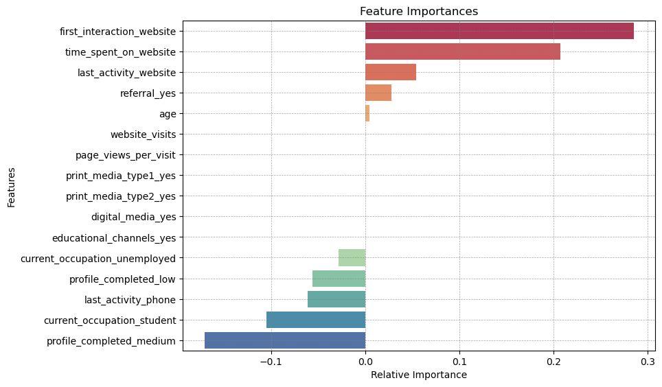

```python
# Plot the feature importance
plt.figure(figsize=(10, 6))
plt.title("Feature Importances")
sns.barplot(
    data=importance_df,
    x="relative_importance",
    y=importance_df.index,
    palette="Spectral",
)
plt.xlabel("Relative Importance")
plt.ylabel("Features")
plt.grid(True, color="grey", linestyle="--", linewidth=0.5, alpha=palette_alpha)

# Adjust layout and show the plot
plt.tight_layout(pad=2.0)
plt.show()
```

**Observations**:

Regularization penalizes weaker encoded features, emphasizing key predictors like engagement metrics, and improves generalization by reducing reliance on low-impact variables.

- **Key Features**: The top contributors are first_interaction_website and time_spent_on_website, emphasizing the significance of early and sustained user engagement in driving lead conversions.
- **Supporting Features**: Moderate impact comes from last_activity_website and referral_yes, reflecting the relevance of recent website interactions and referrals in the conversion process. Age also shows a small but positive contribution, indicating its minor influence in predicting leads.
- **Negative Contributions**: The negative coefficients for categories like profile_completed_medium and current_occupation_student indicate these are less favorable for conversion compared to their reference categories, such as profile_completed_high and current_occupation_professional, which are inherently more aligned with successful lead conversion.
- **Others**: The remaining features show minimal impact, suggesting limited relevance to the model’s predictive power. Features related to print and digital media have zero influence, underscoring their lack of role in predicting lead conversions.

## Model 2: Decision Tree

### Building Decision Tree Model

```python
# Building Decision Tree model
model_dt = DecisionTreeClassifier(random_state=1)

# Fitting the model on the training data
model_dt.fit(X_train, y_train)
```

```
DecisionTreeClassifier(random_state=1)
```

### Evaluating Model Performance

```
Training Performance:
              precision    recall  f1-score   support

           0       1.00      1.00      1.00      2264
           1       1.00      1.00      1.00       964

    accuracy                           1.00      3228
   macro avg       1.00      1.00      1.00      3228
weighted avg       1.00      1.00      1.00      3228
```

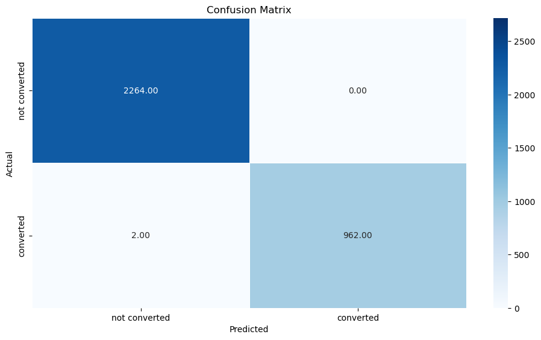

```
Testing Performance:
              precision    recall  f1-score   support

           0       0.85      0.86      0.86       971
           1       0.67      0.65      0.66       413

    accuracy                           0.80      1384
   macro avg       0.76      0.76      0.76      1384
weighted avg       0.80      0.80      0.80      1384
```

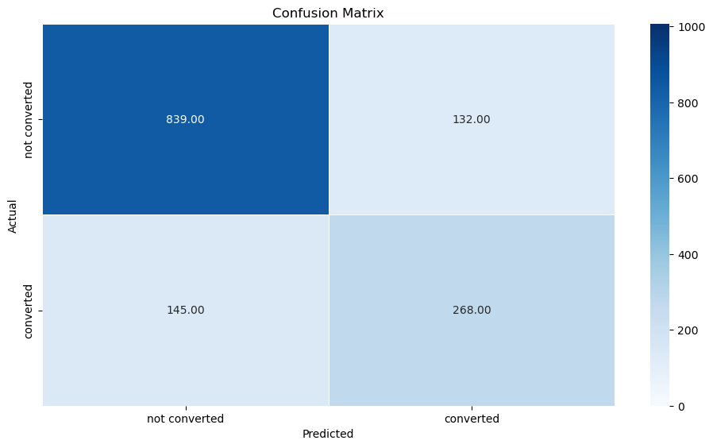

```python
# Predicting on the training and testing data
y_train_pred_dt = model_dt.predict(X_train)
y_test_pred_dt = model_dt.predict(X_test)

# Evaluating the model on the training data
print("Training Performance:")
model_dt_train_metrics = metrics_score(y_train, y_train_pred_dt)

# Evaluating the model on the testing data
print("Testing Performance:")
model_dt_test_metrics = metrics_score(y_test, y_test_pred_dt)
```

**Observations**:

- **Train Dataset**: The decision tree achieves perfect metrics (accuracy, precision, and recall of 1.00), with only 2 false negatives. This indicates overfitting, as the model memorizes training patterns rather than generalizing effectively.
- **Test Dataset**: Performance declines significantly due to overfitting, with an accuracy of 0.80, precision of 0.67, and recall of 0.65 for the converted class. The confusion matrix highlights 145 false negatives and 132 false positives, underscoring difficulties in identifying converted leads and generalizing to unseen data.
- **Hyperparameter Tuning**: Adjustments such as reducing max_depth, increasing min_samples_leaf, or applying class_weight can mitigate overfitting, enhancing generalization and better balancing recall and precision to support the business objective of maximizing lead identification.

### Hyperparameter Tuning

The imbalance in the target variable is addressed by setting the class_weight hyperparameter to {0: 0.3, 1: 0.7}, ensuring higher importance is placed on converted leads (class 1) during model training. Hyperparameter tuning is performed using GridSearchCV to optimize the decision tree’s performance by identifying the best parameter combinations:

- **max_depth**: Limits the tree’s maximum depth to balance model complexity and overfitting.
- **criterion**: Evaluates split quality using either Gini impurity or information gain (entropy).
- **min_samples_leaf**: Specifies the minimum samples required for a leaf node, ensuring meaningful splits and reducing overfitting.

```python
# Building the decision tree model with initial parameters
model_dt_tuned = DecisionTreeClassifier(random_state=1, class_weight={0: 0.3, 1: 0.70})
```

```python
# Define the grid of parameters to search
param_grid_dt = {
    "max_depth": list(range(2, 10)),
    "criterion": ["gini", "entropy"],
    "min_samples_leaf": [1, 5, 10, 20],
}

# Initialize and run the grid search with cross-validation
gs_dt = GridSearchCV(model_dt_tuned, param_grid_dt, scoring="recall", n_jobs=-1, cv=5)
gs_dt = gs_dt.fit(X_train, y_train)

# Get the best parameters and best score
best_params_dt = gs_dt.best_params_
best_score_dt = gs_dt.best_score_

print(f"Best Parameters: {best_params_dt}")
print(f"Best Recall Score: {best_score_dt:.4f}")
```

```
Best Parameters: {'criterion': 'entropy', 'max_depth': 3, 'min_samples_leaf': 1}
Best Recall Score: 0.9067
```

```python
# Update the classifier with the best found parameters
model_dt_tuned = gs_dt.best_estimator_

# Fit the tuned model on the training data
model_dt_tuned.fit(X_train, y_train)
```

```
DecisionTreeClassifier(class_weight={0: 0.3, 1: 0.7}, criterion='entropy',
                       max_depth=3, random_state=1)
```

### Evaluating Model Performance

```
Training Performance with Best Estimator:
              precision    recall  f1-score   support

           0       0.95      0.75      0.84      2264
           1       0.60      0.91      0.72       964

    accuracy                           0.79      3228
   macro avg       0.78      0.83      0.78      3228
weighted avg       0.85      0.79      0.80      3228
```

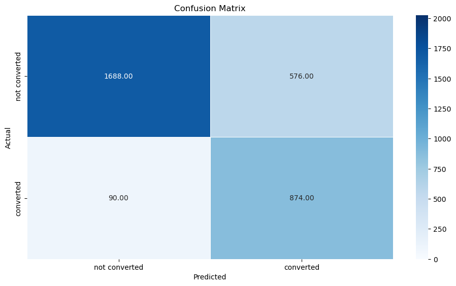

```
Testing Performance with Best Estimator:
              precision    recall  f1-score   support

           0       0.94      0.73      0.82       971
           1       0.58      0.89      0.70       413

    accuracy                           0.78      1384
   macro avg       0.76      0.81      0.76      1384
weighted avg       0.83      0.78      0.79      1384
```

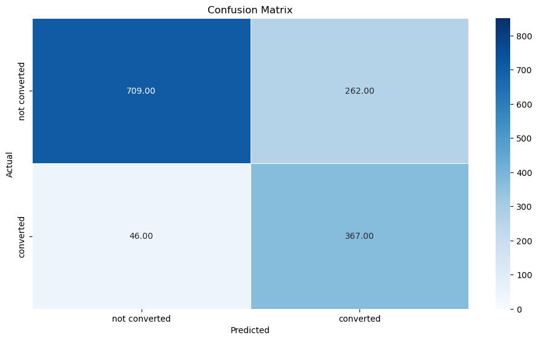

```python
# Checking model performance on the training dataset
y_train_pred_dt_tuned = model_dt_tuned.predict(X_train)
y_test_pred_dt_tuned = model_dt_tuned.predict(X_test)

# Evaluate the model on the training data
print("Training Performance with Best Estimator:")
model_dt_tuned_train_metrics = metrics_score(y_train, y_train_pred_dt_tuned)

# Evaluate the model on the testing data
print("Testing Performance with Best Estimator:")
model_dt_tuned_test_metrics = metrics_score(y_test, y_test_pred_dt_tuned)
```

**Observations**:

- **Improved Generalization**: Hyperparameter tuning reduces overfitting and balances performance across training and test datasets, improving the model’s practical utility.
- **Train Dataset**: Accuracy decreases from 1.00 to 0.79, reflecting improved generalization. Recall decreases slightly from 1.00 to 0.91, increasing false negatives from 2 to 90, while precision drops from 1.00 to 0.60, raising false positives from 0 to 576.
- **Test Dataset**: Accuracy decreases slightly from 0.80 to 0.78, highlighting the trade-off between precision and recall. Recall improves significantly from 0.65 to 0.89, reducing false negatives from 145 to 46, while precision drops from 0.67 to 0.58, increasing false positives from 132 to 262.
- **Business Relevance**: The tuned model prioritizes recall, aligning with the business objective of maximizing lead identification. Although increased false positives introduce some inefficiencies, the significant reduction in missed opportunities ensures the model effectively identifies high-potential leads, supporting strategic goals.